# ADP R_BASIC_1

jakinpilla 2019-05-07

Loading housing data —————————————————————————–

```r
read.table('./data/housing_data.csv') -> boston
names(boston) <- c('crim', 'zn', 'indus', 'chas', 'nox', 'rm', 'age', 'dis', 'rad',
                   'tax', 'ptratio', 'black', 'lstat', 'medv')
head(boston)
```

```
##      crim zn indus chas   nox    rm  age    dis rad tax ptratio  black
## 1 0.00632 18  2.31    0 0.538 6.575 65.2 4.0900   1 296    15.3 396.90
## 2 0.02731  0  7.07    0 0.469 6.421 78.9 4.9671   2 242    17.8 396.90
## 3 0.02729  0  7.07    0 0.469 7.185 61.1 4.9671   2 242    17.8 392.83
## 4 0.03237  0  2.18    0 0.458 6.998 45.8 6.0622   3 222    18.7 394.63
## 5 0.06905  0  2.18    0 0.458 7.147 54.2 6.0622   3 222    18.7 396.90
## 6 0.02985  0  2.18    0 0.458 6.430 58.7 6.0622   3 222    18.7 394.12
##   lstat medv
## 1  4.98 24.0
## 2  9.14 21.6
## 3  4.03 34.7
## 4  2.94 33.4
## 5  5.33 36.2
## 6  5.21 28.7
```

```r
# crim :: per capita crime rate by town
# zn :: proportion of residential land zoned for lots over 25,000 sq.ft.
# indus :: proportion of non-retail business acres per town
# chas :: charles river dummy variable (=1 if tract bounds river; 0 otherwise)
# nox :: nitric oxides concentration (parts per 10 million)
# rm :: average number of rooms per dwelling
# age :: proportion of owner-occupied units built prior to 1940
# dis :: weighted distance to five Boston employment centers
# rad :: index of accessibility to radial highways
# tax :: full-value property-tax rate per $10,000
# ptratio :: pupil-teacher ratio by town
# black :: 1000(Bk - 0.63)^2 where Bk is the proportion of blacks by town
# lstat :: % lower status of the population
# medv :: Median value of owner-occupied homes in $1000's
```

Reading various file types ————————————————————————–

```r
read.table('./data/students.txt', sep='\t', header=F) -> student ; head(student) # If there is no header...
```

```
##          V1                     V2                            V3      V4
## 1 1141206/1 Obolo, Oluremi Olawale       oluremi.obolo@kcl.ac.uk Current
## 2 1220318/1           Azizi, Ozhan         ozhan.azizi@kcl.ac.uk Current
## 3 1229815/1             Zain, Sara           sara.zain@kcl.ac.uk Current
## 4 1319061/1       Naumov, Valentin     valentin.naumov@kcl.ac.uk Current
## 5 1322382/3      Vasile, Tudor Dan        tudor.vasile@kcl.ac.uk Current
## 6 1331498/1   Stampelos, Stamatios stamatios.stampelos@kcl.ac.uk Current
##                              V5 V6
## 1        Computing And Security NA
## 2 Advanced Software Engineering NA
## 3        Computing And Security NA
## 4        Computing And Security NA
## 5        Computing And Security NA
## 6        Computing And Security NA
```

```r
d1 <- read.table("./data/student-mat.csv",sep=";",header=TRUE) ; head(d1) # deliminator is ";"
```

```
##   school sex age address famsize Pstatus Medu Fedu     Mjob     Fjob
## 1     GP   F  18       U     GT3       A    4    4  at_home  teacher
## 2     GP   F  17       U     GT3       T    1    1  at_home    other
## 3     GP   F  15       U     LE3       T    1    1  at_home    other
## 4     GP   F  15       U     GT3       T    4    2   health services
## 5     GP   F  16       U     GT3       T    3    3    other    other
## 6     GP   M  16       U     LE3       T    4    3 services    other
##       reason guardian traveltime studytime failures schoolsup famsup paid
## 1     course   mother          2         2        0       yes     no   no
## 2     course   father          1         2        0        no    yes   no
## 3      other   mother          1         2        3       yes     no  yes
## 4       home   mother          1         3        0        no    yes  yes
## 5       home   father          1         2        0        no    yes  yes
## 6 reputation   mother          1         2        0        no    yes  yes
##   activities nursery higher internet romantic famrel freetime goout Dalc
## 1         no     yes    yes       no       no      4        3     4    1
## 2         no      no    yes      yes       no      5        3     3    1
## 3         no     yes    yes      yes       no      4        3     2    2
## 4        yes     yes    yes      yes      yes      3        2     2    1
## 5         no     yes    yes       no       no      4        3     2    1
## 6        yes     yes    yes      yes       no      5        4     2    1
##   Walc health absences G1 G2 G3
## 1    1      3        6  5  6  6
## 2    1      3        4  5  5  6
## 3    3      3       10  7  8 10
## 4    1      5        2 15 14 15
## 5    2      5        4  6 10 10
## 6    2      5       10 15 15 15
```

```r
student <- read_delim("data/student.txt",  "\t", col_names = FALSE); student # delim is "tap" and no header...
```

```
## # A tibble: 4 x 4
##      X1 X2       X3    X4
##   <dbl> <chr> <dbl> <dbl>
## 1   101 hong    175    65
## 2   201 lee     185    85
## 3   301 kim     173    60
## 4   401 park    180    70
```

```r
student1 <- read_delim("data/student1.txt", "\t"); student1 # delim is "tap" and there is header...
```

```
## # A tibble: 4 x 4
##    번호 이름     키 몸무게
##   <dbl> <chr> <dbl>  <dbl>
## 1   101 hong    175     65
## 2   201 lee     185     85
## 3   301 kim     173     60
## 4   401 park    180     70
```

```r
student2 <- read_delim("data/student2.txt", ";"); student2  # delim is ";" and there is header...
```

```
## # A tibble: 4 x 4
##    번호 이름     키 몸무게
##   <dbl> <chr> <dbl>  <dbl>
## 1   101 hong    175     65
## 2   201 lee     185     85
## 3   301 kim     173     60
## 4   401 park    180     70
```

In case when NA has certain character…

```r
student3 <- read_delim("data/student3.txt", "\t", na= '-') # converet '-' to NA...
```

strip.white —————————————————————————

```r
student4 <- read_csv("data/student4.txt", col_names = FALSE); head(student4)
```

```
## # A tibble: 4 x 4
##      X1 X2       X3    X4
##   <dbl> <chr> <dbl> <dbl>
## 1   101 hong    175    65
## 2   201 lee     185    85
## 3   301 kim     173    60
## 4   401 park    180    70
```

```r
white_wine <- read.table('./data/winequality-white.csv', strip.white = F, sep=';',
                         header=T); head(white_wine)
```

```
##   fixed.acidity volatile.acidity citric.acid residual.sugar chlorides
## 1           7.0             0.27        0.36           20.7     0.045
## 2           6.3             0.30        0.34            1.6     0.049
## 3           8.1             0.28        0.40            6.9     0.050
## 4           7.2             0.23        0.32            8.5     0.058
## 5           7.2             0.23        0.32            8.5     0.058
## 6           8.1             0.28        0.40            6.9     0.050
##   free.sulfur.dioxide total.sulfur.dioxide density   pH sulphates alcohol
## 1                  45                  170  1.0010 3.00      0.45     8.8
## 2                  14                  132  0.9940 3.30      0.49     9.5
## 3                  30                   97  0.9951 3.26      0.44    10.1
## 4                  47                  186  0.9956 3.19      0.40     9.9
## 5                  47                  186  0.9956 3.19      0.40     9.9
## 6                  30                   97  0.9951 3.26      0.44    10.1
##   quality
## 1       6
## 2       6
## 3       6
## 4       6
## 5       6
## 6       6
```

```r
white_wine <- read.table('./data/winequality-white.csv',sep=';',
                         header=T); head(white_wine)
```

```
##   fixed.acidity volatile.acidity citric.acid residual.sugar chlorides
## 1           7.0             0.27        0.36           20.7     0.045
## 2           6.3             0.30        0.34            1.6     0.049
## 3           8.1             0.28        0.40            6.9     0.050
## 4           7.2             0.23        0.32            8.5     0.058
## 5           7.2             0.23        0.32            8.5     0.058
## 6           8.1             0.28        0.40            6.9     0.050
##   free.sulfur.dioxide total.sulfur.dioxide density   pH sulphates alcohol
## 1                  45                  170  1.0010 3.00      0.45     8.8
## 2                  14                  132  0.9940 3.30      0.49     9.5
## 3                  30                   97  0.9951 3.26      0.44    10.1
## 4                  47                  186  0.9956 3.19      0.40     9.9
## 5                  47                  186  0.9956 3.19      0.40     9.9
## 6                  30                   97  0.9951 3.26      0.44    10.1
##   quality
## 1       6
## 2       6
## 3       6
## 4       6
## 5       6
## 6       6
```

na.rm=T —————————————————————————

```r
student3
```

```
## # A tibble: 4 x 4
##    번호 이름     키 몸무게
##   <dbl> <chr> <dbl>  <dbl>
## 1   101 hong    175     65
## 2   201 lee     185     85
## 3   301 kim     173     NA
## 4   401 park     NA     70
```

```r
mean(student3$키)
```

```
## [1] NA
```

```r
mean(student3$키, na.rm=T)
```

```
## [1] 177.6667
```

EDA basic (glimpse, plot(numeric_var ~ factor_var, data))

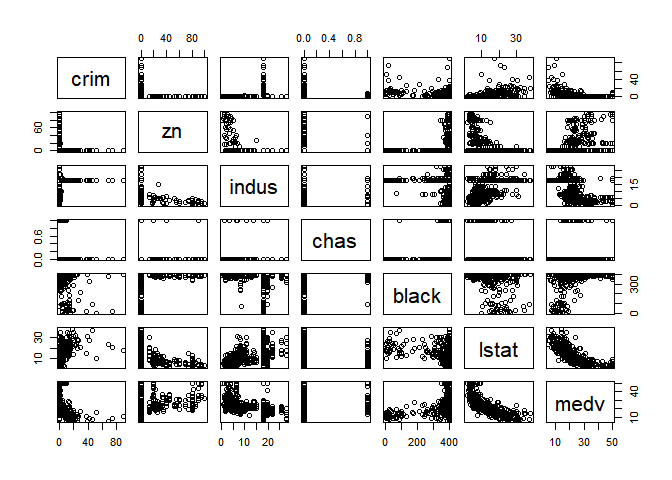

```r
# summary(boston)
plot(boston[, c('crim', 'zn', 'indus', 'chas', 'black', 'lstat', 'medv')])
```

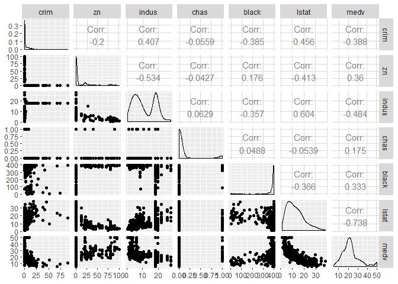

```r
ggpairs(boston[, c('crim', 'zn', 'indus', 'chas', 'black', 'lstat', 'medv')])
```

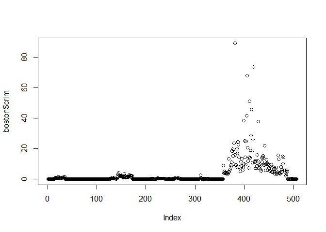

```r
plot(boston$crim) # if one numeric var, index on axis-x
```

iris —————————————————————————

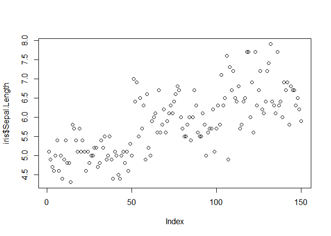

```r
plot(iris$Sepal.Length)
```

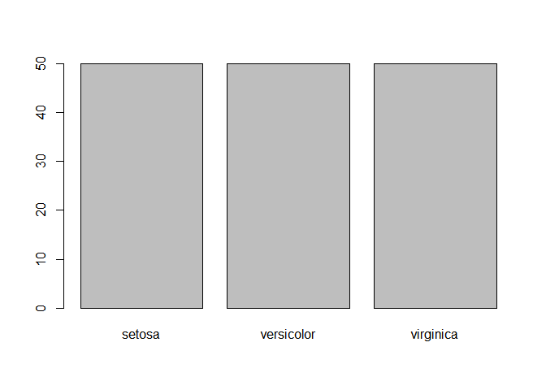

```r
plot(iris$Species) # only one factor var, factor on x-axis , frequency on y-axis
```

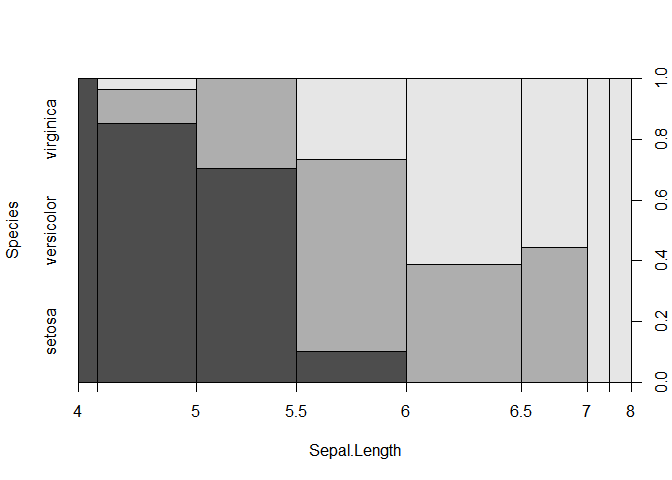

```r
plot(Species ~ Sepal.Length, data=iris) # factor on LHS, numeric on RHS => mosaic plot
```

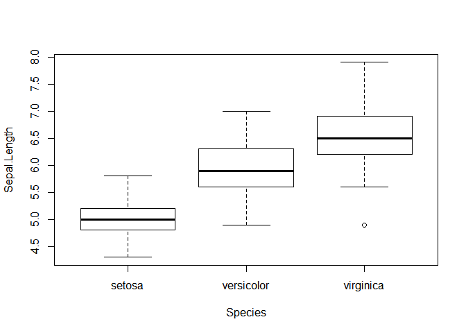

```r
plot(Sepal.Length ~ Species, data=iris) # numericl on LHS , factor on RHS ==> boxplot
```

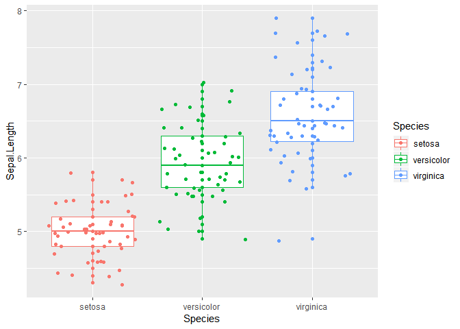

```r
iris %>%
  ggplot(aes(Species,Sepal.Length, col = Species)) +
  geom_boxplot() +
  geom_point() + geom_jitter()
```

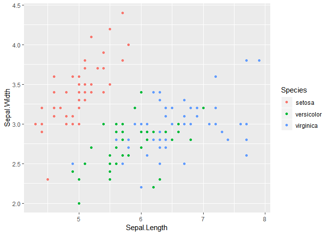

```r
iris %>%
  ggplot(aes(Sepal.Length, Sepal.Width, col = Species)) + geom_point()
```

GGally::ggpairs() —————————————————————————

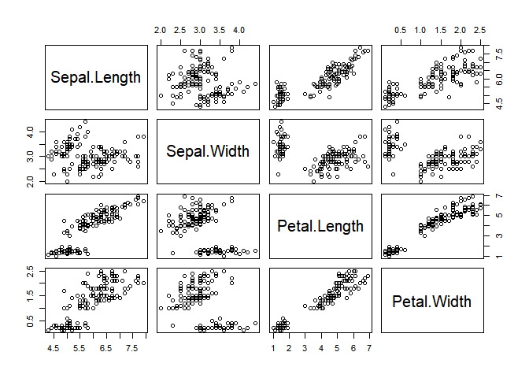

```r
pairs(iris[, 1:4])
```

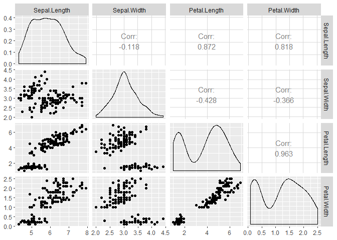

```r
iris %>% select_if(is.numeric) %>% ggpairs
```

Correlations Matrix —————————————————————————

```r
cor(iris[, 1:4])
```

```
##              Sepal.Length Sepal.Width Petal.Length Petal.Width
## Sepal.Length    1.0000000  -0.1175698    0.8717538   0.8179411
## Sepal.Width    -0.1175698   1.0000000   -0.4284401  -0.3661259
## Petal.Length    0.8717538  -0.4284401    1.0000000   0.9628654
## Petal.Width     0.8179411  -0.3661259    0.9628654   1.0000000
```

```r
round(cor(iris[, 1:4]), 2)
```

```
##              Sepal.Length Sepal.Width Petal.Length Petal.Width
## Sepal.Length         1.00       -0.12         0.87        0.82
## Sepal.Width         -0.12        1.00        -0.43       -0.37
## Petal.Length         0.87       -0.43         1.00        0.96
## Petal.Width          0.82       -0.37         0.96        1.00
```

```r
round(cor(iris[, 1:4]), 1)
```

```
##              Sepal.Length Sepal.Width Petal.Length Petal.Width
## Sepal.Length          1.0        -0.1          0.9         0.8
## Sepal.Width          -0.1         1.0         -0.4        -0.4
## Petal.Length          0.9        -0.4          1.0         1.0
## Petal.Width           0.8        -0.4          1.0         1.0
```

Titanic —-

Convert whitespace("") value into NA —————————————————————————

```r
tbl_df(fread('./data/titanic3.csv', data.table = F)) -> titanic
# summary(titanic)
titanic$cabin <- ifelse(titanic$cabin == "", NA, titanic$cabin)
titanic$cabin[1:10]
```

```
##  [1] "B5"      "C22 C26" "C22 C26" "C22 C26" "C22 C26" "E12"     "D7"
##  [8] "A36"     "C101"    NA
```

Replace all "" into NA notation ———————————————

```r
titanic %>%
  mutate_all(funs(ifelse(. == "", NA, .)))
```

[output not shown]

Replace all NA values into 0 —————————————–

```r
titanic %>% replace(is.na(.), 0) -> titanic_na_zero_replaced; titanic_na_zero_replaced
```

```
## # A tibble: 1,309 x 14
##    pclass survived name  sex     age sibsp parch ticket  fare cabin
##     <int>    <int> <chr> <chr> <dbl> <int> <int> <chr>  <dbl> <chr>
##  1      1        1 Alle~ fema~ 29        0     0 24160  211.  B5
##  2      1        1 Alli~ male   0.92     1     2 113781 152.  C22 ~
##  3      1        0 Alli~ fema~  2        1     2 113781 152.  C22 ~
##  4      1        0 Alli~ male  30        1     2 113781 152.  C22 ~
##  5      1        0 Alli~ fema~ 25        1     2 113781 152.  C22 ~
##  6      1        1 Ande~ male  48        0     0 19952   26.6 E12
##  7      1        1 Andr~ fema~ 63        1     0 13502   78.0 D7
##  8      1        0 Andr~ male  39        0     0 112050   0   A36
##  9      1        1 Appl~ fema~ 53        2     0 11769   51.5 C101
## 10      1        0 Arta~ male  71        0     0 PC 17~  49.5 0
## # ... with 1,299 more rows, and 4 more variables: embarked <chr>,
## #   boat <chr>, body <dbl>, home.dest <chr>
```

Replace all "" values into "NA in character columns ————————————————–

```r
titanic %>%
  mutate_if(is.character, funs(ifelse(. == "", "NA", .))) -> titanic_1

titanic_1
```

```
## # A tibble: 1,309 x 14
##    pclass survived name  sex     age sibsp parch ticket  fare cabin
##     <int>    <int> <chr> <chr> <dbl> <int> <int> <chr>  <dbl> <chr>
##  1      1        1 Alle~ fema~ 29        0     0 24160  211.  B5
##  2      1        1 Alli~ male   0.92     1     2 113781 152.  C22 ~
##  3      1        0 Alli~ fema~  2        1     2 113781 152.  C22 ~
##  4      1        0 Alli~ male  30        1     2 113781 152.  C22 ~
##  5      1        0 Alli~ fema~ 25        1     2 113781 152.  C22 ~
##  6      1        1 Ande~ male  48        0     0 19952   26.6 E12
##  7      1        1 Andr~ fema~ 63        1     0 13502   78.0 D7
##  8      1        0 Andr~ male  39        0     0 112050   0   A36
##  9      1        1 Appl~ fema~ 53        2     0 11769   51.5 C101
## 10      1        0 Arta~ male  71        0     0 PC 17~  49.5 <NA>
## # ... with 1,299 more rows, and 4 more variables: embarked <chr>,
## #   boat <chr>, body <int>, home.dest <chr>
```

Replace all NA values into “NA” in character columns ————————————————–

```r
titanic_1 %>%
  mutate_if(is.character, funs(ifelse(is.na(.), "NA", .))) -> titanic_2

titanic_2
```

```
## # A tibble: 1,309 x 14
##    pclass survived name  sex     age sibsp parch ticket  fare cabin
##     <int>    <int> <chr> <chr> <dbl> <int> <int> <chr>  <dbl> <chr>
##  1      1        1 Alle~ fema~ 29        0     0 24160  211.  B5
##  2      1        1 Alli~ male   0.92     1     2 113781 152.  C22 ~
##  3      1        0 Alli~ fema~  2        1     2 113781 152.  C22 ~
##  4      1        0 Alli~ male  30        1     2 113781 152.  C22 ~
##  5      1        0 Alli~ fema~ 25        1     2 113781 152.  C22 ~
##  6      1        1 Ande~ male  48        0     0 19952   26.6 E12
##  7      1        1 Andr~ fema~ 63        1     0 13502   78.0 D7
##  8      1        0 Andr~ male  39        0     0 112050   0   A36
##  9      1        1 Appl~ fema~ 53        2     0 11769   51.5 C101
## 10      1        0 Arta~ male  71        0     0 PC 17~  49.5 NA
## # ... with 1,299 more rows, and 4 more variables: embarked <chr>,
## #   boat <chr>, body <int>, home.dest <chr>
```

Replace all NA values into 0 in numeric columns ————————————————–

```r
titanic_2 %>%
  mutate_if(is.numeric, funs(ifelse(is.na(.), 0, .))) -> titanic_3

titanic_3
```

```
## # A tibble: 1,309 x 14
##    pclass survived name  sex     age sibsp parch ticket  fare cabin
##     <int>    <int> <chr> <chr> <dbl> <int> <int> <chr>  <dbl> <chr>
##  1      1        1 Alle~ fema~ 29        0     0 24160  211.  B5
##  2      1        1 Alli~ male   0.92     1     2 113781 152.  C22 ~
##  3      1        0 Alli~ fema~  2        1     2 113781 152.  C22 ~
##  4      1        0 Alli~ male  30        1     2 113781 152.  C22 ~
##  5      1        0 Alli~ fema~ 25        1     2 113781 152.  C22 ~
##  6      1        1 Ande~ male  48        0     0 19952   26.6 E12
##  7      1        1 Andr~ fema~ 63        1     0 13502   78.0 D7
##  8      1        0 Andr~ male  39        0     0 112050   0   A36
##  9      1        1 Appl~ fema~ 53        2     0 11769   51.5 C101
## 10      1        0 Arta~ male  71        0     0 PC 17~  49.5 NA
## # ... with 1,299 more rows, and 4 more variables: embarked <chr>,
## #   boat <chr>, body <dbl>, home.dest <chr>
```

At once ———————————————————————

```r
titanic %>%
  mutate_if(is.character, funs(ifelse(. == "", "NA", .))) %>%
  mutate_if(is.character, funs(ifelse(is.na(.), "NA", .))) %>%
  mutate_if(is.numeric, funs(ifelse(is.na(.), 0, .))) -> titanic_replaced

titanic_replaced
```

```
## # A tibble: 1,309 x 14
##    pclass survived name  sex     age sibsp parch ticket  fare cabin
##     <int>    <int> <chr> <chr> <dbl> <int> <int> <chr>  <dbl> <chr>
##  1      1        1 Alle~ fema~ 29        0     0 24160  211.  B5
##  2      1        1 Alli~ male   0.92     1     2 113781 152.  C22 ~
##  3      1        0 Alli~ fema~  2        1     2 113781 152.  C22 ~
##  4      1        0 Alli~ male  30        1     2 113781 152.  C22 ~
##  5      1        0 Alli~ fema~ 25        1     2 113781 152.  C22 ~
##  6      1        1 Ande~ male  48        0     0 19952   26.6 E12
##  7      1        1 Andr~ fema~ 63        1     0 13502   78.0 D7
##  8      1        0 Andr~ male  39        0     0 112050   0   A36
##  9      1        1 Appl~ fema~ 53        2     0 11769   51.5 C101
## 10      1        0 Arta~ male  71        0     0 PC 17~  49.5 NA
## # ... with 1,299 more rows, and 4 more variables: embarked <chr>,
## #   boat <chr>, body <dbl>, home.dest <chr>
```

Imputating 0 with mean or median value in body columns —————————–

```r
titanic_replaced %>%
  mutate_if(is.numeric, funs(ifelse(.==0, mean(.), .)))
```

```
## # A tibble: 1,309 x 14
##    pclass survived name  sex     age sibsp parch ticket  fare cabin
##     <int>    <dbl> <chr> <chr> <dbl> <dbl> <dbl> <chr>  <dbl> <chr>
##  1      1    1     Alle~ fema~ 29    0.499 0.385 24160  211.  B5
##  2      1    1     Alli~ male   0.92 1     2     113781 152.  C22 ~
##  3      1    0.382 Alli~ fema~  2    1     2     113781 152.  C22 ~
##  4      1    0.382 Alli~ male  30    1     2     113781 152.  C22 ~
##  5      1    0.382 Alli~ fema~ 25    1     2     113781 152.  C22 ~
##  6      1    1     Ande~ male  48    0.499 0.385 19952   26.6 E12
##  7      1    1     Andr~ fema~ 63    1     0.385 13502   78.0 D7
##  8      1    0.382 Andr~ male  39    0.499 0.385 112050  33.3 A36
##  9      1    1     Appl~ fema~ 53    2     0.385 11769   51.5 C101
## 10      1    0.382 Arta~ male  71    0.499 0.385 PC 17~  49.5 NA
## # ... with 1,299 more rows, and 4 more variables: embarked <chr>,
## #   boat <chr>, body <dbl>, home.dest <chr>
```

```r
mean(titanic_replaced$body)
```

```
## [1] 14.86478
```

```r
median(titanic_replaced$body)
```

```
## [1] 0
```

```r
median_value <- median(titanic$body, na.rm = T)

titanic_replaced %>%
  mutate(body = ifelse(body==0, median_value, body))
```

```
## # A tibble: 1,309 x 14
##    pclass survived name  sex     age sibsp parch ticket  fare cabin
##     <int>    <int> <chr> <chr> <dbl> <int> <int> <chr>  <dbl> <chr>
##  1      1        1 Alle~ fema~ 29        0     0 24160  211.  B5
##  2      1        1 Alli~ male   0.92     1     2 113781 152.  C22 ~
##  3      1        0 Alli~ fema~  2        1     2 113781 152.  C22 ~
##  4      1        0 Alli~ male  30        1     2 113781 152.  C22 ~
##  5      1        0 Alli~ fema~ 25        1     2 113781 152.  C22 ~
##  6      1        1 Ande~ male  48        0     0 19952   26.6 E12
##  7      1        1 Andr~ fema~ 63        1     0 13502   78.0 D7
##  8      1        0 Andr~ male  39        0     0 112050   0   A36
##  9      1        1 Appl~ fema~ 53        2     0 11769   51.5 C101
## 10      1        0 Arta~ male  71        0     0 PC 17~  49.5 NA
## # ... with 1,299 more rows, and 4 more variables: embarked <chr>,
## #   boat <chr>, body <dbl>, home.dest <chr>
```

```r
titanic_replaced %>%
  mutate(body = ifelse(body==0, median_value, body)) -> titanic_imputed

titanic_imputed
```

```
## # A tibble: 1,309 x 14
##    pclass survived name  sex     age sibsp parch ticket  fare cabin
##     <int>    <int> <chr> <chr> <dbl> <int> <int> <chr>  <dbl> <chr>
##  1      1        1 Alle~ fema~ 29        0     0 24160  211.  B5
##  2      1        1 Alli~ male   0.92     1     2 113781 152.  C22 ~
##  3      1        0 Alli~ fema~  2        1     2 113781 152.  C22 ~
##  4      1        0 Alli~ male  30        1     2 113781 152.  C22 ~
##  5      1        0 Alli~ fema~ 25        1     2 113781 152.  C22 ~
##  6      1        1 Ande~ male  48        0     0 19952   26.6 E12
##  7      1        1 Andr~ fema~ 63        1     0 13502   78.0 D7
##  8      1        0 Andr~ male  39        0     0 112050   0   A36
##  9      1        1 Appl~ fema~ 53        2     0 11769   51.5 C101
## 10      1        0 Arta~ male  71        0     0 PC 17~  49.5 NA
## # ... with 1,299 more rows, and 4 more variables: embarked <chr>,
## #   boat <chr>, body <dbl>, home.dest <chr>
```

Convert NA values into median values ————————————————————————–

```r
titanic %>%
  mutate_if(is.numeric, funs(ifelse(is.na(.), median(., na.rm=T), .))) -> t_tmp; # summary(t_tmp)

head(t_tmp)
```

```
## # A tibble: 6 x 14
##   pclass survived name  sex     age sibsp parch ticket  fare cabin embarked
##    <int>    <int> <chr> <chr> <dbl> <int> <int> <chr>  <dbl> <chr> <chr>
## 1      1        1 Alle~ fema~ 29        0     0 24160  211.  B5    S
## 2      1        1 Alli~ male   0.92     1     2 113781 152.  C22 ~ S
## 3      1        0 Alli~ fema~  2        1     2 113781 152.  C22 ~ S
## 4      1        0 Alli~ male  30        1     2 113781 152.  C22 ~ S
## 5      1        0 Alli~ fema~ 25        1     2 113781 152.  C22 ~ S
## 6      1        1 Ande~ male  48        0     0 19952   26.6 E12   S
## # ... with 3 more variables: boat <chr>, body <int>, home.dest <chr>
```

```r
# '_imp' suffix imputation --------------------------------------------------------------------------
titanic %>%
  mutate_if(is.numeric, funs(imp=ifelse(is.na(.), median(., na.rm=T), .))) -> t_tmp; # summary(t_tmp) # notice the "imp="

head(t_tmp)
```

```
## # A tibble: 6 x 21
##   pclass survived name  sex     age sibsp parch ticket  fare cabin embarked
##    <int>    <int> <chr> <chr> <dbl> <int> <int> <chr>  <dbl> <chr> <chr>
## 1      1        1 Alle~ fema~ 29        0     0 24160  211.  B5    S
## 2      1        1 Alli~ male   0.92     1     2 113781 152.  C22 ~ S
## 3      1        0 Alli~ fema~  2        1     2 113781 152.  C22 ~ S
## 4      1        0 Alli~ male  30        1     2 113781 152.  C22 ~ S
## 5      1        0 Alli~ fema~ 25        1     2 113781 152.  C22 ~ S
## 6      1        1 Ande~ male  48        0     0 19952   26.6 E12   S
## # ... with 10 more variables: boat <chr>, body <int>, home.dest <chr>,
## #   pclass_imp <int>, survived_imp <int>, age_imp <dbl>, sibsp_imp <int>,
## #   parch_imp <int>, fare_imp <dbl>, body_imp <int>
```

```r
# str(t_tmp)
```

Eliminate all data which has at least a NA ————————————————————————–

```r
na.omit(titanic)
```

```
## # A tibble: 32 x 14
##    pclass survived name  sex     age sibsp parch ticket  fare cabin
##     <int>    <int> <chr> <chr> <dbl> <int> <int> <chr>  <dbl> <chr>
##  1      1        0 Alli~ male     30     1     2 113781 152.  C22 ~
##  2      1        0 Asto~ male     47     1     0 PC 17~ 228.  C62 ~
##  3      1        0 Bran~ male     48     0     0 PC 17~  50.5 B10
##  4      1        0 Cave~ male     36     1     0 19877   78.8 C46
##  5      1        0 Cros~ male     70     1     1 WE/P ~  71   B22
##  6      1        0 Doug~ male     50     1     0 PC 17~ 106.  C86
##  7      1        0 Dull~ male     39     0     0 PC 17~  29.7 A18
##  8      1        0 Gee,~ male     47     0     0 111320  38.5 E63
##  9      1        0 Grah~ male     38     0     1 PC 17~ 153.  C91
## 10      1        0 Harr~ male     40     0     0 112059   0   B94
## # ... with 22 more rows, and 4 more variables: embarked <chr>, boat <chr>,
## #   body <int>, home.dest <chr>
```

Convert data classes ————————————————————————–

```r
titanic_imputed$pclass <- as.factor(titanic_imputed$pclass)
# titanic$ticket <- as.character(titanic$ticket)
titanic_imputed$survived <- factor(titanic_imputed$survived, levels=c(0,1), labels=c('dead', 'survived'))
glimpse(titanic_imputed)
```

```
## Observations: 1,309
## Variables: 14
## $ pclass    <fct> 1, 1, 1, 1, 1, 1, 1, 1, 1, 1, 1, 1, 1, 1, 1, 1, 1, 1...
## $ survived  <fct> survived, survived, dead, dead, dead, survived, surv...
## $ name      <chr> "Allen, Miss. Elisabeth Walton", "Allison, Master. H...
## $ sex       <chr> "female", "male", "female", "male", "female", "male"...
## $ age       <dbl> 29.00, 0.92, 2.00, 30.00, 25.00, 48.00, 63.00, 39.00...
## $ sibsp     <int> 0, 1, 1, 1, 1, 0, 1, 0, 2, 0, 1, 1, 0, 0, 0, 0, 0, 0...
## $ parch     <int> 0, 2, 2, 2, 2, 0, 0, 0, 0, 0, 0, 0, 0, 0, 0, 0, 1, 1...
## $ ticket    <chr> "24160", "113781", "113781", "113781", "113781", "19...
## $ fare      <dbl> 211.3375, 151.5500, 151.5500, 151.5500, 151.5500, 26...
## $ cabin     <chr> "B5", "C22 C26", "C22 C26", "C22 C26", "C22 C26", "E...
## $ embarked  <chr> "S", "S", "S", "S", "S", "S", "S", "S", "S", "C", "C...
## $ boat      <chr> "2", "11", "NA", "NA", "NA", "3", "10", "NA", "D", "...
## $ body      <dbl> 155, 155, 155, 135, 155, 155, 155, 155, 155, 22, 124...
## $ home.dest <chr> "St Louis, MO", "Montreal, PQ / Chesterville, ON", "...
```

Check the data class ————————————————————————–

```r
class(titanic$embarked) # characeter
```

```
## [1] "character"
```

```r
levels(titanic$embarked) # NULL
```

[output not shown]

```r
table(titanic$embarked)
```

```
##
##       C   Q   S
##   2 270 123 914
```

```r
titanic$embarked <- as.factor(titanic$embarked)
table(titanic$embarked)
```

```
##
##       C   Q   S
##   2 270 123 914
```

```r
table(titanic$embarked, useNA='always')
```

```
##
##         C    Q    S <NA>
##    2  270  123  914    0
```

```r
titanic$cabin <- as.factor(titanic$cabin)
table(titanic$cabin)
```

```
##
##             A10             A11             A14             A16
##               1               1               1               1
##             A18             A19             A20             A21
##               1               1               1               1
##             A23             A24             A26             A29
##               1               1               1               1
##             A31             A32             A34             A36
##               1               1               3               1
##              A5              A6              A7              A9
##               1               1               1               1
##             B10            B101            B102             B11
##               1               1               1               1
##             B18             B19             B20             B22
##               2               1               2               2
##             B24             B26             B28              B3
##               1               1               2               1
##             B30             B35             B36             B37
##               1               2               1               1
##             B38             B39              B4             B41
##               1               1               1               2
##             B42             B45             B49              B5
##               1               2               2               2
##             B50     B51 B53 B55     B52 B54 B56 B57 B59 B63 B66
##               1               3               1               5
##         B58 B60             B61             B69             B71
##               3               1               2               2
##             B73             B77             B78             B79
##               1               2               2               1
##             B80         B82 B84             B86             B94
##               1               1               1               1
##         B96 B98            C101            C103            C104
##               4               3               1               1
##            C105            C106            C110            C111
##               1               2               1               1
##            C116            C118            C123            C124
##               2               1               2               2
##            C125            C126            C128            C130
##               2               2               1               1
##            C132            C148              C2         C22 C26
```

[output cut: 40 more lines]

```
##               3               1               1               1
##             E40             E44             E45             E46
##               1               2               1               2
##             E49             E50             E52             E58
##               1               2               1               1
##             E60             E63             E67             E68
##               1               1               2               1
##             E77              E8               F           F E46
##               1               2               1               1
##           F E57           F E69           F G63           F G73
##               1               1               2               2
##              F2             F33             F38              F4
##               4               4               1               4
##              G6               T
##               5               1
```

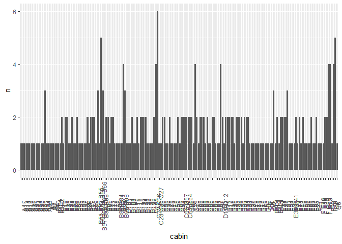

```r
cabin <- as.data.frame(table(titanic$cabin)); names(cabin) <- c('room', 'count')

titanic %>%
  mutate(cabin = as.character(cabin)) %>%
  select(cabin) %>%
  group_by(cabin) %>%
  tally() %>%
  arrange(desc(n)) %>%
  filter(cabin != "") -> df.cabin

df.cabin %>%
  ggplot(aes(cabin, n)) +
  geom_bar(stat = "identity") +
  theme(legend.position = 'none', axis.text.x = element_text(angle = 90))
```

Imdb Dataset ————————————————————————–